# COMS474_574_HW1_Solns

```python
import numpy as np
from sklearn.linear_model import LinearRegression
import matplotlib.pyplot as plt
```

Below are solutions using Python and the numpy and scikit-learn libraries. While the code will look different if you used another language, the basic procedures and work-flow are the same.

Some of the code below uses Python functions or libraries (like itertools, pandas) that were not necessary, and can be implemented using simpler methods (like multiple for loops, lists, or dictionaries). If any of the steps are not clear, let us know and we can explain how they work or provide an alternative way to do it.

Also, since the Problem 1 data is random, your plots may vary in the specific values, though the general trends should be the same.

Lastly, below there are more printouts and plots than you were asked to do. They are included to help you understand the results. Let us know if you have trouble understanding any of the solutions.

# Problem1

```python
#(a)
X = np.array([[0**0, 0**1, 0**2, 0**3], [5**0, 5**1, 5**2, 5**3], [8**0, 8**1, 8**2, 8**3], [12**0, 12**1, 12**2, 12**3]])
Y = np.array([10, 5, 12, 0])
reg = LinearRegression(fit_intercept=False).fit(X, Y)
print("Coefficients: %s"%(reg.coef_))

## If you set fit_intercept=True, the intercept a0 is stored separately
#print("Intercept: %f"%(reg.intercept_))
```

```
Coefficients: [10.         -7.01190476  1.69345238 -0.09821429]
```

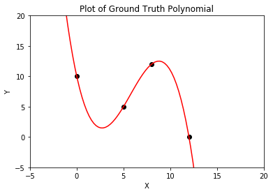

```python
#(b)
x = np.linspace(-5, 20,100)
y = []
for each in x:
    y.append(reg.coef_[0]*(each**0) + reg.coef_[1]*(each**1) + reg.coef_[2]*(each**2) + reg.coef_[3]*(each**3))

y= np.array(y)
plt.figure()
plt.scatter(np.array([0, 5, 8, 12]), Y, marker='o', color='black')
plt.plot(x, y, color='red')
plt.xlabel("X")
plt.ylabel("Y")
# set axes range
plt.xlim(-5, 20)
plt.ylim(-5, 20)
plt.title('Plot of Ground Truth Polynomial')
plt.show()
```

1.(c). It does not matter for this particular polynomial and data points it is fitting. The polynomial fits the four data points perfectly. The residuals are all 0. Thus, this polynomial would have 0 total loss for any other loss function (since any combination of 0's is 0).

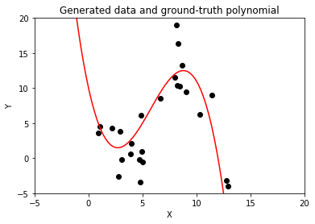

```
MSE on training set using ground-truth polynomial: 13.88
MSE on validation set using ground-truth polynomial: 13.00
MSE on all 30 data points using ground-truth polynomial: 13.59
```

```python
#(d)
n_samples = 30
new_x = np.random.uniform(0,15,n_samples)
#new_x = np.array(sorted(new_x))
new_x = np.array(new_x)
new_X = []

iid_noise = np.random.normal(0, np.sqrt(10), n_samples)
new_y = []
for i in range(len(new_x)):
    new_X.append([new_x[i]**0, new_x[i]**1, new_x[i]**2, new_x[i]**3])
new_X = np.array(new_X)
y_hat = reg.predict(new_X)
new_y = y_hat + iid_noise
plt.figure()
plt.scatter(new_x, new_y, marker='o', color='black')
plt.plot(x, y, color='red')
plt.xlabel("X")
plt.ylabel("Y")
# set axes range
plt.xlim(-5, 20)
plt.ylim(-5, 20)
plt.title('Generated data and ground-truth polynomial')
plt.show()

#we can easily calculate the MSE here on the training and test sets
ground_truth_mse_20 = np.sum( (new_y[:20] - y_hat[:20])**2  )/20
print('MSE on training set using ground-truth polynomial: %.2f'%( ground_truth_mse_20  ) )
ground_truth_mse_10 = np.sum( (new_y[20:] - y_hat[20:])**2  )/10
print('MSE on validation set using ground-truth polynomial: %.2f'%( ground_truth_mse_10  ) )
ground_truth_mse_30 = np.sum( (new_y[:] - y_hat[:])**2  )/30
print('MSE on all 30 data points using ground-truth polynomial: %.2f'%( ground_truth_mse_30  ) )
```

```
denoting the mean point using the black line
```

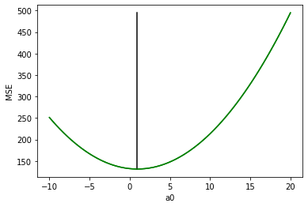

```python
#(e) MSE
mse_residuals = []
constant_y = np.linspace(-10, 20, 100)
for each in constant_y:
    mse_residuals.append(np.sum((np.full(n_samples, each) - new_y)**2) / len(new_x))
mse_residuals = np.array(mse_residuals)

print('denoting the mean point using the black line')
plt.plot(constant_y, mse_residuals, color='green')
plt.plot([np.mean(new_y), np.mean(new_y)], [min(mse_residuals), max(mse_residuals)],'black')
plt.plot(constant_y, mse_residuals, color='green')
plt.xlabel("a0")
plt.ylabel("MSE")
plt.show()
```

```
denoting the median point using the black line
```

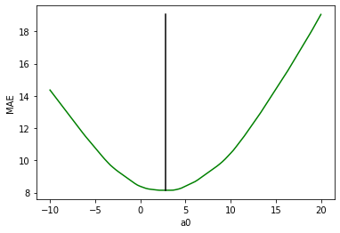

```python
#(e) MAE
mae_residuals = []
for each in constant_y:
    mae_residuals.append(np.sum(np.abs(np.full(n_samples, each) - new_y)) / len(new_x))
mae_residuals = np.array(mae_residuals)

print('denoting the median point using the black line')
plt.plot(constant_y, mae_residuals, color='green')
plt.plot([np.median(new_y), np.median(new_y)], [min(mae_residuals), max(mae_residuals)],'black')
plt.xlabel("a0")
plt.ylabel("MAE")
plt.show()
```

1.(e) Special Loss function -- in the directions, there was no summation. The notation $x_i$ may have also been unclear. Consequently, as told in office hours, we will accept any good-faith attempt for this part.

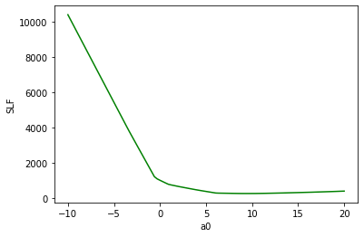

```python
#(e) Special Loss function(slf)
slf_residuals = []
for each in constant_y:
  residuals = new_y - np.full(n_samples, each)
  slf_total_loss = 0.0

  for res_i, x_i in zip(residuals, new_x):
    if res_i < 0:
      l_res_i = -0.2*res_i
    else:
      l_res_i = 10*res_i

    l_res_i = l_res_i/(abs(x_i - 5)+0.01)

    slf_total_loss = slf_total_loss + l_res_i

  slf_residuals.append(slf_total_loss)

slf_residuals = np.array(slf_residuals)

plt.plot(constant_y, slf_residuals, color='green')
plt.xlabel("a0")
plt.ylabel("SLF")
plt.show()
```

1.(f) i. the loss function prefers over-estimating. Eg, using $a_0=20$ is above all/most of the data points, so the residuals are negative and not as heavily penalized as under-predicting (e.g. $a_0 = -5$)

ii. The loss function is more sensitive to the fit around $x=5$. If a sample has an $x$ value around $5$, the fraction $$\frac{1}{|x - 5|+0.01}$$ is large giving more weight to the total loss. This is in contrast to the uniform weighting $1/n$ that we see with other loss functions.

```python
#(g)
mean = np.mean(new_y)
median = np.median(new_y)
print("Mean of y values: %f"%(mean))
print("Median of y values: %f"%(median))
```

```
Mean of y values: 0.943904
Median of y values: 2.813117
```

The mean value is the best $a_0$ when we use MSE. The median value is the best $a_0$ when we use the MAE. We can see that from the plots above. We can also derive it. (you do not need to have written the following for full credit)

When using MSE, we seek $$\min_{a_0} \frac{1}{n} \sum_{i=1}^n (y_i- a_0)^2$$. Take the derivative with respect to $a_0$, set it equal to 0,

$$\frac{1}{n} \sum_{i=1}^n 2(y_i- a_0)(-1) = 0$$

Cancel the constants, rearrange, and we get $$\sum_{i=1}^n y_i = na_0$$ yeilding the optimal $a_0$ as the mean. (to be rigorous, we should take the second derivative, which is positive, so we are good)

For the median, recall that the absolute value function $f(z) = |z|$ has a derivative of -1 for negative z and +1 for positive z, hence $sign(z)$. When using MAE, we seek $$\min_{a_0} \frac{1}{n} \sum_{i=1}^n |y_i- a_0|$$. Take the derivative with respect to $a_0$, set it equal to 0, and we get $$ -\frac{1}{n} \sum_{i=1}^n sign(y_i- a_0) = 0$$ Hence, any solution $a_0$ that has an even number of +1 and -1 terms in the summation will be $0$, hence $a_0$ should be above and below an equal number of samples. The median is defined to be that value.

```python
#see new_x and new_y  -- these should not be sorted prior to the following steps
print(new_x)
print(new_y)
```

```
[ 4.99427109  4.72365999 13.52649949 12.67036847  4.93409136  8.017317
  2.19911798  8.65588321  3.90474403 12.79633518 10.34230994 13.86876169
  8.33229912  3.09270274  3.98333095  8.42081501  1.03117067  6.62543862
 11.44901024  4.79247546  9.0387174  14.52043383  2.78702521 12.9381218
  0.87984694 14.10446763  4.87276438  2.91478328  8.16947518  8.18912878]
[ -0.55053226  -0.24334137 -14.26020924  -6.17975741   0.95188163
  11.51784305   4.33155513  13.29725022   0.60977075  -3.22119694
   6.23750749 -17.47385234  16.35627867  -0.14100649   2.05518244
  10.24693919   4.53373338   8.58225661   9.03749374  -3.39114164
   9.44050446 -35.25437868  -2.59677508  -4.01964901   3.57105074
 -24.36828956   6.10391112   3.78022293  18.96751094  10.39634467]
```

Notice: There appears to be a problem using the LinearRegression library, as it does not always return correct solutions for large $p$. You should get perfect fitting polynomials once $p=n-1$, and for $p>n-1$ there are an infinite number of perfectly fitting solutions (and thus 0 training error). Standardizing the results helps, but this homework was designed in part for you to see the effects of using features in their natural scales.

Since the homework suggested using the LinearRegression library, those results are included here. We expect the training error to flatline at 0, even though the validation error should skyrocket.

```python
# 1.(h).i   Create an array of features for the x values in the data set.  The first 20 rows are for training.
Y = []
X = []
for x in new_x:
    X.append( [x**i for i in range(0,31) ] )
for y in new_y:
    Y.append( [y] )
Y = np.array(Y)
X = np.array(X)
print(X)
print(Y)
```

[output not shown]

[output cut: 215 more lines]

```
 [ 10.24693919]
 [  4.53373338]
 [  8.58225661]
 [  9.03749374]
 [ -3.39114164]
 [  9.44050446]
 [-35.25437868]
 [ -2.59677508]
 [ -4.01964901]
 [  3.57105074]
 [-24.36828956]
 [  6.10391112]
 [  3.78022293]
 [ 18.96751094]
 [ 10.39634467]]
```

```python
#1.(h).ii - fit
train_mse_lst = []

for p in range(1,32):

    poly_reg = LinearRegression(fit_intercept=False).fit(X[:20,:p], Y[:20,:])

    train_hat_y =  poly_reg.predict(X[:20,:p])

    train_mse = np.sum((Y[:20,:] - train_hat_y)**2) / len(train_hat_y)

    train_mse_lst.append(train_mse)

train_mse_arr = np.array(train_mse_lst)
```

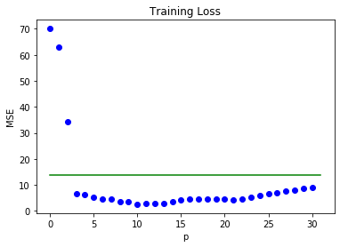

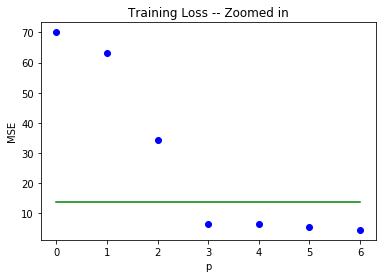

```python
#1.(h).ii - plot

plt.scatter(range(31), train_mse_arr, color='blue',)
plt.plot([0,31], [ground_truth_mse_20, ground_truth_mse_20], color='green')
plt.title("Training Loss")
plt.xlabel("p")
plt.ylabel("MSE")
plt.show()

p=6
plt.scatter(range(p+1), train_mse_arr[:p+1], color='blue',)
plt.plot([0,p], [ground_truth_mse_20, ground_truth_mse_20], color='green')
plt.title("Training Loss -- Zoomed in")
plt.xlabel("p")
plt.ylabel("MSE")
plt.show()
```

1.(h).iii

Some comments:

-- We see big improvements in the training loss in going from $p=0$ up to $p=3$. After that, it flatlines (future improvements from $p$ to $p+1$ are tiny) for a while before it increases again (we don't expect that part).

-- we should see that the $p=3$ is below the green line (since the ground truth polynomial was an option when the solver was looking for the best cubic function for the training data)

-- We should not see the training error increase (that is a problem with the library)

```python
#1.(h).iv - fit
test_mse_lst = []

for p in range(1,32):

    #refit to first 20 samples
    poly_reg = LinearRegression(fit_intercept=False).fit(X[:20,:p], Y[:20,:])

    #predict on last 10 samples
    test_hat_y =  poly_reg.predict(X[20:,:p])

    test_mse = np.sum((Y[20:,:] - test_hat_y)**2) / len(test_hat_y)

    test_mse_lst.append(test_mse)

test_mse_arr = np.array(test_mse_lst)
```

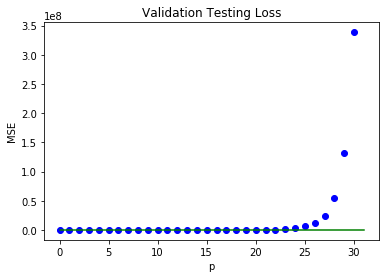

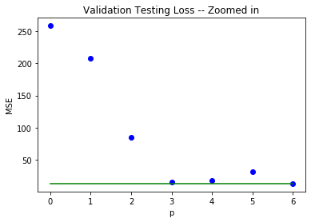

```python
#1.(h).v - plots (you did not need to show both plots)

plt.scatter(range(31), test_mse_arr, color='blue',)
plt.plot([0,31], [ground_truth_mse_10, ground_truth_mse_10], color='green')
plt.title("Validation Testing Loss")
plt.xlabel("p")
plt.ylabel("MSE")
plt.show()

p=6
plt.scatter(range(p+1), test_mse_arr[:p+1], color='blue',)
plt.plot([0,p], [ground_truth_mse_10, ground_truth_mse_10], color='green')
plt.title("Validation Testing Loss -- Zoomed in")
plt.xlabel("p")
plt.ylabel("MSE")
plt.show()
```

1.(h).v We see that as $p$ increases, the error increases dramatically for large $p$ (most times this script is run). If you zoom in closer (you were not required to do this), you can see that performance fluctuates. Generally, we do expect to see that the validation loss is above the green line. If you re-run the script, sometimes there is improvement initially with increasing $p$, and sometimes there is not.

Regardless of the library used to fit the regression, you should have seen the validation MSE and the ground truth MSE get large as $p$ increased. Pay attention to the scale on the vertical axis. Part of the goal of this exercise was for you to see how even though the training error goes to zero and stays there (which by itself suggests the models are equally good), increasingly high polynomials drastically overfit the data and are terrible for predicting new values.

Some of you correctly guessed it even before implementing that it would be a bad idea to fit 20 data points, drawn from a cubic function, using a 30th degree polynomial. You might not have guessed just how bad it can be. Also, it was easy to forsee that in this example, but much tougher to guess when overfitting might occur with more complex machine learning techniques.

```
9.87682482605859
```

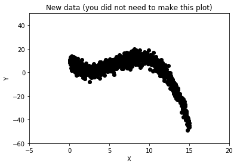

```python
#1.(h).vi  1000
x1000 = np.random.uniform(0,15,1000)
X1000 = []
iid_noise_1000 = np.random.normal(0, np.sqrt(10), 1000)
y1000 = []
for x in x1000:
    X1000.append( [x**i for i in range(0,31) ] )
X1000 = np.array(X1000)
y_hat1000 = reg.predict(X1000[:,:4])
y1000 = y_hat1000 + iid_noise_1000

ground_truth_mse_1000 = np.mean( iid_noise_1000**2 )
print(ground_truth_mse_1000)

# you did not need to generate this plot
plt.figure()
plt.scatter(x1000, y1000, marker='o', color='black')
plt.xlabel("X")
plt.ylabel("Y")
# set axes range
plt.xlim(-5, 20)
plt.ylim(-60, 50)
plt.title('New data (you did not need to make this plot)')
plt.show()
```

```python
#1.(h).vi - fit , mse of 1000
test_mse_lst = []

for p in range(1,32):

    #refit to first 20 samples
    poly_reg = LinearRegression(fit_intercept=False).fit(X[:20,:p], Y[:20,:])

    #predict on 1000 samples
    test_hat_y =  poly_reg.predict(X1000[:,:p])

    test_mse = np.sum((y1000.flatten() - test_hat_y.flatten())**2 / len(test_hat_y.flatten()))

    test_mse_lst.append(test_mse)

test_mse_arr = np.array(test_mse_lst)
```

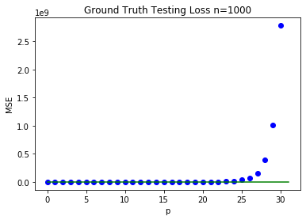

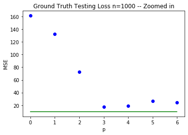

```python
#1.(h).vi - plots

plt.scatter(range(31), test_mse_arr, color='blue',)
plt.plot([0,31], [ground_truth_mse_1000, ground_truth_mse_1000], color='green')
plt.title("Ground Truth Testing Loss n=1000")
plt.xlabel("p")
plt.ylabel("MSE")
plt.show()

#you did not need two plots
plt.figure()
p=6
plt.scatter(range(p+1), test_mse_arr[:p+1], color='blue',)
plt.plot([0,p], [ground_truth_mse_1000, ground_truth_mse_1000], color='green')
plt.title("Ground Truth Testing Loss n=1000 -- Zoomed in")
plt.xlabel("p")
plt.ylabel("MSE")
plt.show()
```

1.(h).vii To evaluate how good a model is, we like to have lots of data not was used for fitting to evaluate the model. In practice, we might only have 10 samples, but here we pretend we have many more. Although it varies each time you re-run the script, we see that generally the 10 sample validation set's curves are fairly similar to those we get with 1000 samples.

1.(h).viii We can solve $$ mse(0) + \lambda*0 = mse(30) + \lambda*30$$ $$\lambda = (mse(0) - mse(30))/30$$ If you got perfect training fit for large $p$, then your $mse(30)=0$

As requested for this problem, the $\lambda$ here is chosen for visualization purposes, though there are some special $\lambda$ values you will use later on.

```python
# fit with all data, keep track of coefficients

train_mse_lst = []
coeff_abs = [] #store sum of abs val of coeff
coeff_sqr = [] #store square of coeff

for p in range(1,32):

    poly_reg = LinearRegression(fit_intercept=False).fit(X[:,:p], Y[:,:])
    print('\nCoefficients for p='+str(p-1))
    print(poly_reg.coef_)
    coeff_abs.append( np.sum( np.abs( poly_reg.coef_) ) )
    coeff_sqr.append( np.sum(  poly_reg.coef_**2 ) )

    train_hat_y =  poly_reg.predict(X[:,:p])

    train_mse = np.sum((Y - train_hat_y)**2) / len(train_hat_y)

    train_mse_lst.append(train_mse)

train_mse_arr = np.array(train_mse_lst)
# print(coeff_abs)

# for penalty p
lamda =(train_mse_arr[0] - train_mse_arr[-1])/30
tot_compl_p= np.array(train_mse_arr) + lamda*np.array(range(31) )

#for penalty sum abs coeff
lamda =(train_mse_arr[0] - train_mse_arr[-1])/( coeff_abs[-1]-coeff_abs[0]   )
# print(lamda)
tot_compl_abs = np.array(train_mse_arr) +lamda*np.array(coeff_abs)

#for penalty sum sqr coeff
lamda =(train_mse_arr[0] - train_mse_arr[-1])/( coeff_sqr[-1]-coeff_sqr[0]   )
tot_compl_sqr = np.array(train_mse_arr) +lamda*np.array(coeff_sqr)
```

```
Coefficients for p=0
[[0.94390357]]

Coefficients for p=1
[[10.37549611 -1.24770067]]

Coefficients for p=2
[[-12.8214949    6.87434833  -0.5125839 ]]

Coefficients for p=3
[[12.81149818 -9.68812567  2.09787059 -0.11323146]]

Coefficients for p=4
[[ 1.06519666e+01 -7.44307367e+00  1.46184197e+00 -4.78240981e-02
  -2.19495064e-03]]

Coefficients for p=5
[[ 8.99844677e+00 -5.13420835e+00  5.37574524e-01  1.02783430e-01
  -1.28764276e-02  2.74313311e-04]]

Coefficients for p=6
[[-1.06177705e+01  2.88290470e+01 -1.79308124e+01  4.57041113e+00
  -5.44475235e-01  3.06666765e-02 -6.66420577e-04]]

Coefficients for p=7
[[-1.87689226e+01  4.48951060e+01 -2.85088463e+01  7.83331577e+00
  -1.07555573e+00  7.76096255e-02 -2.79596649e-03  3.88208496e-05]]

Coefficients for p=8
[[ 8.99131134e-01  2.28162747e+00  4.19717606e+00 -4.55421297e+00
   1.54597525e+00 -2.46916583e-01  2.05151371e-02 -8.60068433e-04
   1.43787124e-05]]

Coefficients for p=9
[[ 2.25732701e+01 -5.01956195e+01  5.16810315e+01 -2.65440597e+01
   7.42914003e+00 -1.20609909e+00  1.17130569e-01 -6.72340735e-03
   2.10721519e-04 -2.78517159e-06]]

Coefficients for p=10
[[-1.24204773e+02  3.48513288e+02 -3.69757914e+02  2.07465356e+02
```

[output cut: 142 more lines]

```
   1.54788632e-26  1.19161379e-25  8.91339137e-25  6.43563974e-24
   4.44730244e-23  2.90856513e-22  1.77267043e-21  9.84582980e-21
   4.81492054e-20  1.95506328e-19  5.85921311e-19  9.24023381e-19
  -5.01051126e-19  1.00735402e-19 -1.05078757e-20  6.09517506e-22
  -1.87381616e-23  2.39046097e-25]]

Coefficients for p=30
[[ 1.61493296e-23  2.57686140e-25  3.92713155e-28 -3.96933409e-30
  -1.42573369e-32 -5.63937458e-34 -1.01302927e-33 -3.64057175e-33
  -5.66130322e-33  7.66006744e-32  1.24885116e-30  1.32683947e-29
   1.22110746e-28  1.04162363e-27  8.43028857e-27  6.52349000e-26
   4.82674812e-25  3.39834747e-24  2.25602752e-23  1.39221609e-22
   7.81605463e-22  3.85863129e-21  1.58021673e-20  4.77380710e-20
   7.59288988e-20 -4.08462186e-20  8.16147700e-21 -8.46489560e-22
   4.88342778e-23 -1.49341810e-24  1.89550303e-26]]
```

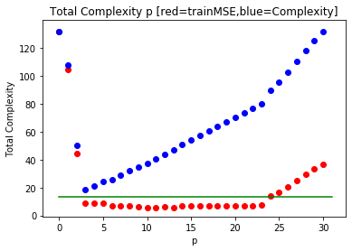

```python
# plot total complexity

plt.scatter(range(31), train_mse_arr, color='red',)
plt.scatter(range(31), tot_compl_p, color='blue',)
plt.plot([0,31], [ground_truth_mse_30, ground_truth_mse_30], color='green')
plt.title("Total Complexity p [red=trainMSE,blue=Complexity]")
plt.xlabel("p")
plt.ylabel("Total Complexity")
plt.show()
```

We plotted in red the training error for reference (the total complexity is that red curve plus a line with slope $\lambda$)

Although it varies each time you re-run the script, in many cases there is a V shape to the curve, where there is a quick decrease (where the decreases in training loss dominate), followed by a slow flat increase as the training error is relatively flat and the complexity penalty takes over. In several runs of the script, we found $p=3$ is typically the minimum of the (blue) total complexity curve.

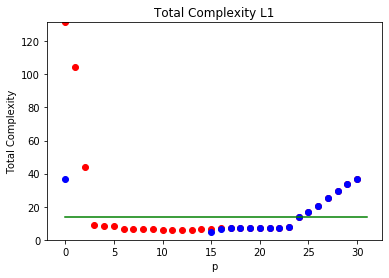

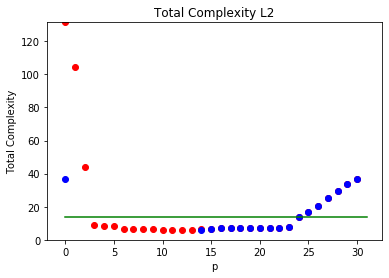

```python
#1.(h).ix
# plot total complexity for other plots

plt.scatter(range(31), train_mse_arr, color='red',)
plt.scatter(range(31), tot_compl_abs, color='blue',)
plt.plot([0,31], [ground_truth_mse_30, ground_truth_mse_30], color='green')
plt.title("Total Complexity L1")
plt.xlabel("p")
plt.ylabel("Total Complexity")
plt.ylim(0,max( max(train_mse_arr), max(tot_compl_sqr)  ))
plt.show()

plt.figure()
plt.scatter(range(31), train_mse_arr, color='red',)
plt.scatter(range(31), tot_compl_sqr, color='blue')
plt.plot([0,31], [ground_truth_mse_30, ground_truth_mse_30], color='green')
plt.title("Total Complexity L2")
plt.xlabel("p")
plt.ylabel("Total Complexity")
plt.ylim(0,max( max(train_mse_arr), max(tot_compl_sqr)  ))
plt.show()
```

1.(h).ix (discussion) The 30th order model returned using LinearRegression library (in multiple runs of this script) had tiny coefficients, not just for the higher order terms (eg since $x^{30}$ is huge we do expect $a_{30}$ to be small to compensate) but even for the intercept and linear terms. This results in a negative $\lambda$ and bad plots, since the $p=0$ model usually has an $a_0$ usually around 2-5.

In practice for linear regression, the intercept $a_0$ is usually not penalized, so that only the slope is. Having no penalty on $a_0$ also centers the residuals, which is a typical modeling assumption. Since we did not go into depth in lecture on this, the instructions included the penalty on the $a_0$.

# Problem 1 (i) More samples

```
10.309187077107737
```

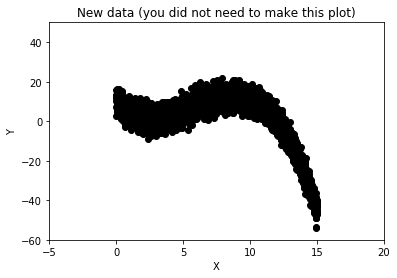

```python
#1.(i).i
x5000 = np.random.uniform(0,15,5000)
X5000 = []
iid_noise_5000 = np.random.normal(0, np.sqrt(10), 5000)
y5000 = []
for x in x5000:
    X5000.append( [x**i for i in range(0,31) ] )
X5000 = np.array(X5000)
y_hat5000 = reg.predict(X5000[:,:4])
y5000 = y_hat5000 + iid_noise_5000

ground_truth_mse_5000 = np.mean( iid_noise_5000**2 )
print(ground_truth_mse_5000)

# you did not need to generate this plot
plt.figure()
plt.scatter(x5000, y5000, marker='o', color='black')
plt.xlabel("X")
plt.ylabel("Y")
# set axes range
plt.xlim(-5, 20)
plt.ylim(-60, 50)
plt.title('New data (you did not need to make this plot)')
plt.show()
```

```python
#1.(i).ii - fit and track coefficients  we will use a dictionary, but you could keep separate arrays

# *** NOTICE: If you fit the full $p=30$ model you got different plots, which is fine.
# here we show coefficients for the $p=9$ model just for illustration purposes.

coef= {}
for j in [0,2,4,6,8]:
    coef[j] = []

p=8
for i in range(1,100):

    poly_reg = LinearRegression(fit_intercept=False).fit(X5000[:50*i,:p+1], y5000[:50*i])

    for j in [0,2,4,6,8]:
        coef[j].append(poly_reg.coef_[j])
```

```
To illustrate convergence (while using LinearRegression library), look at what happens when we look at the 8th order model
```

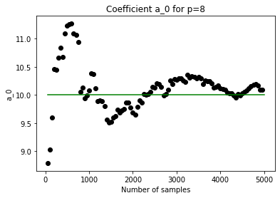

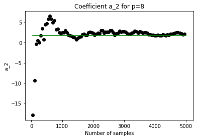

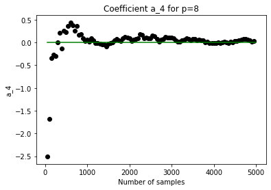

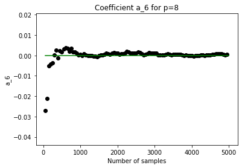

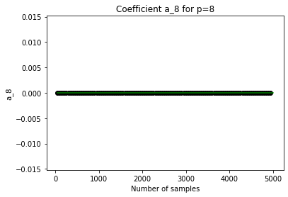

```python
#1.(i).iii
true_coef = {0:reg.coef_[0], 2:reg.coef_[2], 4:0, 6:0, 8:0}
print('\nTo illustrate convergence (while using LinearRegression library), look at what happens when we look at the 8th order model')
for j in [0,2,4,6,8]:
    plt.figure()
    plt.scatter(50*np.array(range(1,100)), coef[j],  color='black')
    plt.plot([50, 5000], [true_coef[j], true_coef[j]],  color='green')
    plt.xlabel('Number of samples')
    plt.ylabel("a_"+str(j))
    plt.title('Coefficient a_'+str(j) +' for p='+str(p))
    plt.show()
```

1.(h).i As mentioned previously, The 30th order model returned using LinearRegression library (in multiple runs of this script) had tiny coefficients, not just for the higher order terms (eg since $x^{30}$ is huge we do expect $a_{30}$ to be small to compensate) but even for the intercept and linear terms. So your plots might have looked quite different than what was expected, which is fine. Here, we only plot for $p=8$ to show that (when using the LinearRegression library) we can see convergence to ground-truth model coefficients in the smaller polynomials, even without any penalties on the parameters.

# Problem2

The below implementation uses a few extra libraries, but these were not necessary. For instance, instead of a Pandas dataframe, you could use csv.reader https://docs.python.org/3/library/csv.html#csv.reader and store the data, with feature names, in a dictionary

```python
import pandas as pd
from itertools import combinations
import operator
```

```python
housing_data = pd.read_csv("housingdata.csv")
```

```python
print(housing_data)
```

```
        CRIM    ZN  INDUS  CHAS    NOX     RM   AGE     DIS  RAD  TAX  \
0    0.00632  18.0   2.31     0  0.538  6.575  65.2  4.0900    1  296
1    0.02731   0.0   7.07     0  0.469  6.421  78.9  4.9671    2  242
2    0.02729   0.0   7.07     0  0.469  7.185  61.1  4.9671    2  242
3    0.03237   0.0   2.18     0  0.458  6.998  45.8  6.0622    3  222
4    0.06905   0.0   2.18     0  0.458  7.147  54.2  6.0622    3  222
..       ...   ...    ...   ...    ...    ...   ...     ...  ...  ...
501  0.06263   0.0  11.93     0  0.573  6.593  69.1  2.4786    1  273
502  0.04527   0.0  11.93     0  0.573  6.120  76.7  2.2875    1  273
503  0.06076   0.0  11.93     0  0.573  6.976  91.0  2.1675    1  273
504  0.10959   0.0  11.93     0  0.573  6.794  89.3  2.3889    1  273
505  0.04741   0.0  11.93     0  0.573  6.030  80.8  2.5050    1  273

     PTRATIO       B  LSTAT  MEDV
0       15.3  396.90   4.98  24.0
1       17.8  396.90   9.14  21.6
2       17.8  392.83   4.03  34.7
3       18.7  394.63   2.94  33.4
4       18.7  396.90   5.33  36.2
..       ...     ...    ...   ...
501     21.0  391.99   9.67  22.4
502     21.0  396.90   9.08  20.6
503     21.0  396.90   5.64  23.9
504     21.0  393.45   6.48  22.0
505     21.0  396.90   7.88  11.9

[506 rows x 14 columns]
```

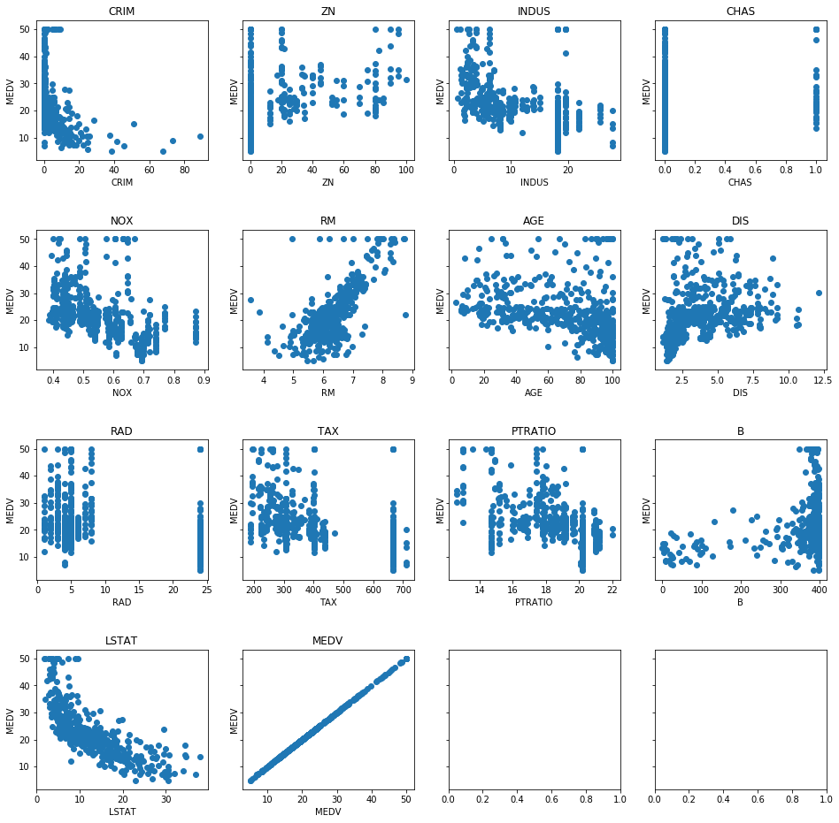

```python
#(a)
fig, ax = plt.subplots(4, 4, sharey=True, figsize=(16,16))
fig.subplots_adjust(hspace=0.5)
i = 0
j = 0
for feature in housing_data.columns.values:
  ax[i, j].scatter(housing_data[feature], housing_data['MEDV'])
  ax[i, j].set_title(feature)
  ax[i, j].set(xlabel=feature, ylabel='MEDV')
  j = j + 1
  if j == 4:
    i = i + 1
    j = 0
```

There are various relationships that might be of interest. For these plots, it is easier to visually detect relevant features that are continuous valued. For instance, RM seems to be linearly correlated with MEDV, while LSTAT is anti-correlated (larger LSTAT means lower MEDV). LSTAT and MEDV to not seem to have a linear relationship, but a linear model may nonetheless capture the anti-correlation. Generally speaking, the less vertical spread for any point on the horizontal axis (eg for LSTAT=20, MEDV values range from about 5 to 30), the better.

Discrete features can also be quite useful, although it can be tougher to spot potential relationships. ZN seems to be correlated. INDUS seems to be anti-correlated. For the others, it is not as clear from these plots alone.

```python
#(b)  There are a few ways of setting this up
# # The most straightforward is using nested for loops and boolean variables to include (or not) a particular feature
# for includeAGE in [True,False]:
#     for includeINDUS in [True,False]:
#         for includeNOX in [True,False]:
#             ...
#                 trainX = []
#                 if includeAGE:
#                     #append AGE values
#                 if includeINDUS:
#                     #append INDUS values
#                 ...
#
#                 #fit
#
#  # The code below uses a function from the Python library itertools which can be handy
## for larger problems.

lst_features = ['AGE', 'INDUS', 'NOX', 'RM', 'TAX']
len_comb = len(lst_features)
lst_comb = []
for l in range(1, len_comb+1):
  comb = combinations(lst_features, l)
  for each in comb:
    lst_comb.append(each)

housing_data_400 = housing_data.head(400)
housing_data_validation = housing_data.tail(100)
housing_fit = LinearRegression(fit_intercept=True)

mse_train_data = []
mse_val_data = []
housing_reg = housing_fit.fit(np.full(len(housing_data_400['MEDV']), 1).reshape(-1, 1), housing_data_400['MEDV'])
medv_hat_train = housing_reg.predict(np.full(len(housing_data_400['MEDV']), 1).reshape(-1, 1))
mse_train = np.sum((medv_hat_train - housing_data_400['MEDV'])**2)/len(housing_data_400['MEDV'])
mse_train_data.append(['constant', mse_train, 0])

medv_hat_val = housing_reg.predict(np.full(len(housing_data_validation), 1).reshape(-1, 1))
mse_val = np.sum((medv_hat_val - housing_data_validation['MEDV'])**2)/len(housing_data_validation['MEDV'])
mse_val_data.append(['constant', mse_val, 0])


for each in lst_comb:
    housing_reg = housing_fit.fit(housing_data_400[list(each)], housing_data_400['MEDV'])
#     print(housing_reg.coef_, housing_reg.intercept_)
    medv_hat_train = housing_reg.predict(housing_data_400[list(each)])
    mse_train = np.sum((medv_hat_train - housing_data_400['MEDV'])**2)/len(housing_data_400['MEDV'])
    mse_train_data.append([str(list(each)), mse_train, len(list(each))])

    medv_hat_val = housing_reg.predict(housing_data_validation[list(each)])
    mse_val = np.sum((medv_hat_val - housing_data_validation['MEDV'])**2)/len(housing_data_validation['MEDV'])
    mse_val_data.append([list(each), mse_val, len(list(each))])

mse_train_df = pd.DataFrame(mse_train_data, columns=['subset','mse','nmbrfeatures'])
mse_val_df = pd.DataFrame(mse_val_data, columns=['subset','mse','nmbrfeatures'])

print('\n\nHere is the Training MSE')
print(mse_train_df)
print('\n\nHere is the Validation MSE')
print(mse_val_df)
#print(sorted_mse_val)
```

```
Here is the Training MSE
                                  subset        mse  nmbrfeatures
0                               constant  83.807010             0
1                                ['AGE']  77.322939             1
2                              ['INDUS']  72.089246             1
3                                ['NOX']  76.094591             1
4                                 ['RM']  36.303311             1
5                                ['TAX']  75.693727             1
6                       ['AGE', 'INDUS']  71.752927             2
7                         ['AGE', 'NOX']  75.448504             2
8                          ['AGE', 'RM']  35.381011             2
9                         ['AGE', 'TAX']  73.592627             2
10                      ['INDUS', 'NOX']  71.980674             2
11                       ['INDUS', 'RM']  35.809186             2
12                      ['INDUS', 'TAX']  71.056828             2
```

[output cut: 55 more lines]

You were not expected to dig deep, but if you look at the above values, you might notice that RM has an interesting property. Subsets that include RM have low training MSE but high validation MSE. What is going on there?

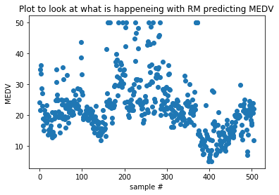

```python
plt.figure()
plt.scatter(range(len(housing_data['MEDV'])), housing_data['MEDV'])
plt.title('Plot to look at what is happeneing with RM predicting MEDV')
plt.xlabel('sample #')
plt.ylabel('MEDV')
plt.show()
```

It appears that the last 106 samples are concentrated in the lower values of MEDV. We might say the first 400 samples (used for training) were not represenative of the last 106 (for testing). Thus, despite a strong correlation between RM and MEDV with the combined data sets, the relationship fit may not have been accurate, especially at the lowest end of MEDV range, which was more common in test set. Later in the semester, we will cover some smarter ways of forming training and test sets to avoid this type of issue. Again, this level of investigation was not expected for HW 1, but we wanted to still point it out.

```python
#(c)-1
best_val_subsets = mse_val_df.sort_values(['mse']).groupby('nmbrfeatures').head(1)
print(best_val_subsets)
```

```
                        subset        mse  nmbrfeatures
20             [AGE, NOX, TAX]  26.044191             3
9                   [AGE, TAX]  26.365439             2
27      [AGE, INDUS, NOX, TAX]  27.272065             4
5                        [TAX]  27.744035             1
31  [AGE, INDUS, NOX, RM, TAX]  54.001443             5
0                     constant  91.601031             0
```

For this data set, it turns out the best subsets of different cardinalities form a complete nesting. TAX, then AGE, then NOX, then INDUS, then RM.

In practice, this does not always happen and especially when there might be complementary or synergistic interactions between variables (we have not discussed this topic yet), we often will not see a complete nesting of optimal subsets.

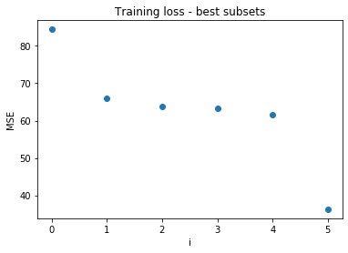

```python
#(c)-2
train_plot_y = []
train_plot_x = []
val_plot_y = []
val_plot_x = []
for _, row in best_val_subsets.iterrows():
  train_plot_y.append(mse_train_df[mse_train_df['subset']==str(row['subset'])]['mse'].values[0])
  val_plot_y.append(row['mse'])
  if row['subset'] == 'constant':
    train_plot_x.append(0)
    val_plot_x.append(0)
  else:
    train_plot_x.append(len(row['subset']))
    val_plot_x.append(len(row['subset']))

#print(train_plot_x)
#print(train_plot_y)

plt.scatter(np.array(train_plot_x), np.array(train_plot_y))
plt.xlabel("i")
plt.ylabel("MSE")
plt.title("Training loss - best subsets")
plt.show()
```

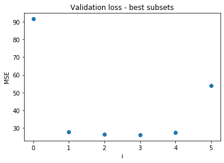

```python
#(c)-2
plt.scatter(np.array(val_plot_x), np.array(val_plot_y))
plt.xlabel("i")
plt.ylabel("MSE")
plt.title("Validation loss - best subsets")
plt.show()
```

In training, we see by including more features, the fit gets better, but that can come at a cost of overfitting. From the plot with the validation data, we can see that just using a constant is underfitting, then using 1-4 variables about the same performance, but then the validation error increases a lot when we use the fifth variable.

```python
#(c)-3
housing_fit = LinearRegression(fit_intercept=True)
mse_train_data = []

housing_reg = housing_fit.fit(np.full(len(housing_data), 1).reshape(-1, 1), housing_data['MEDV'])
medv_hat_train = housing_reg.predict(np.full(len(housing_data), 1).reshape(-1, 1))
mse_train = np.sum((medv_hat_train - housing_data['MEDV'])**2)/len(housing_data['MEDV'])
mse_train_data.append(['constant', mse_train, 0])


for each in lst_comb:
  housing_reg = housing_fit.fit(housing_data[list(each)], housing_data['MEDV'])
  medv_hat_train = housing_reg.predict(housing_data[list(each)])
  mse_train = np.sum((medv_hat_train - housing_data['MEDV'])**2)/len(housing_data)
  mse_train_data.append([str(list(each)), mse_train, len(list(each))])

mse_train_df = pd.DataFrame(mse_train_data, columns=['subset','mse','nmbrfeatures'])
complexity = mse_train_df['mse'] + (mse_train_df['nmbrfeatures'] * 2 * mse_train_df.loc[mse_train_df['subset'] == str(['AGE', 'INDUS', 'NOX', 'RM', 'TAX'])]['mse'].values[0])/len(housing_data)
mse_train_df['complexity'] = complexity
print(mse_train_df)
```

```
                                  subset        mse  nmbrfeatures  complexity
0                               constant  84.419556             0   84.419556
1                                ['AGE']  72.423981             1   72.567413
2                              ['INDUS']  64.666222             1   64.809654
3                                ['NOX']  69.004288             1   69.147720
4                                 ['RM']  43.600552             1   43.743984
5                                ['TAX']  65.887275             1   66.030707
6                       ['AGE', 'INDUS']  64.054645             2   64.341509
7                         ['AGE', 'NOX']  68.251684             2   68.538547
8                          ['AGE', 'RM']  39.653935             2   39.940799
9                         ['AGE', 'TAX']  63.672567             2   63.959431
10                      ['INDUS', 'NOX']  63.986729             2   64.273593
11                       ['INDUS', 'RM']  39.145483             2   39.432347
12                      ['INDUS', 'TAX']  62.141096             2   62.427960
13                         ['NOX', 'RM']  39.218117             2   39.504980
```

[output cut: 18 more lines]

```
                                  subset        mse  nmbrfeatures  complexity
21                  ['AGE', 'RM', 'TAX']  36.299720             3   36.730015
28         ['AGE', 'INDUS', 'RM', 'TAX']  36.291805             4   36.865532
31  ['AGE', 'INDUS', 'NOX', 'RM', 'TAX']  36.288264             5   37.005423
15                         ['RM', 'TAX']  37.096997             2   37.383861
4                                 ['RM']  43.600552             1   43.743984
0                               constant  84.419556             0   84.419556
```

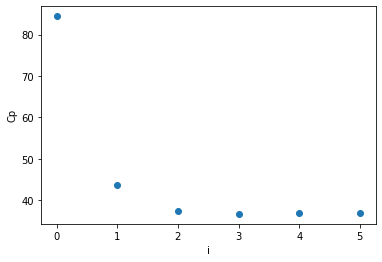

```python
#(c)-3
best_subsets = mse_train_df.sort_values(['complexity']).groupby('nmbrfeatures').head(1)
print(best_subsets)
plt.scatter(np.array(best_subsets['nmbrfeatures']), np.array(best_subsets['complexity']))
plt.xlabel("i")
plt.ylabel("Cp")
plt.show()
```

The total complexity plot, like the validation plot, has the expected decrease initially. They both flatten out around 2 to 3, and there is only a tiny increase in the total complexity (not visible from the plot). If you look at the actual numbers, you can see that even though the mse decreased, the total complexity did increase a little. Overall, this choice of $\lambda$ does not heavily penalize the subsets viewed, and we may need to include several more features before we see a visually distinct increase.

2.(c).iv.ii Note: the directions said to let $\lambda$ range from 0 to the same complexity as the $p=0$th model. The $p=0$th model model is what you should get as $\lambda \to \infty$, since all coefficients will be heavily penalized. The goal was to see how performance varies as a function of the $\lambda$, from the regime $\lambda \approx 0$ where the unpenalized, ordinary-least-squares solution is the model, out to the regime $\lambda \to \infty$ where ridge returns the $p=0$ model. In practice, we can select the $\lambda$ with the lowest validation MSE.

The directions did not give guidance about ranging $\lambda$, so we will accept any good-faith effort for this problem. What regime of $\lambda$ will induce changes is data dependent, though since it is trading off training MSE on the one hand and coefficient magnitudes on the other, it will need to be on a scale for those two properties to fight each other.

Below are plots showing a large range of $\lambda$ values, using a log-log plot to show a large range.

(the homework file was incorrectly updated with ``$\lambda=0$'' as a correction when the homework was reposted with the revised due date)

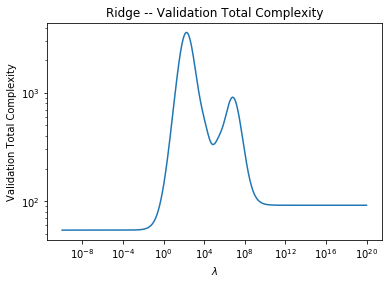

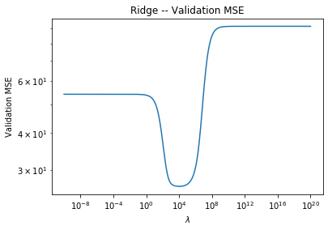

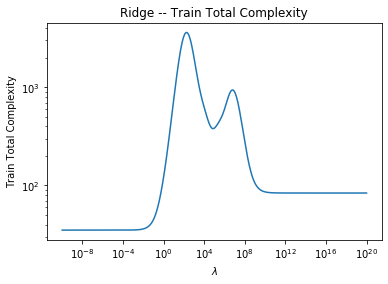

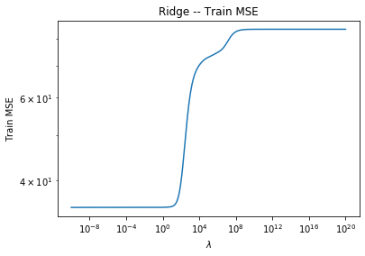

```python
#(c)-4-2
from sklearn.linear_model import Ridge
lamda = 0
ridge_val_complexity = -1
ridge_plot_x = []
ridge_plot_valmse = []
ridge_plot_valcomp = []
ridge_plot_trainmse = []
ridge_plot_traincomp = []

lambdas = [10**i for i in np.linspace(-10,+20,1000)]
for lamda in lambdas:

    ridge_reg = Ridge(alpha=lamda, fit_intercept=True).fit(housing_data_400[['AGE', 'INDUS', 'NOX', 'RM', 'TAX']], housing_data_400['MEDV'])

    ridge_train_hat = ridge_reg.predict( housing_data_400[['AGE', 'INDUS', 'NOX', 'RM', 'TAX']])
    ridge_mse_train = np.sum((housing_data_400['MEDV'] - ridge_train_hat)**2)/len(housing_data_400)
    ridge_train_complexity = ridge_mse_train + lamda * np.sum(ridge_reg.coef_[0:]**2)
    ridge_plot_traincomp.append(ridge_train_complexity)
    ridge_plot_trainmse.append(ridge_mse_train)

    ridge_val_hat = ridge_reg.predict(housing_data_validation[['AGE', 'INDUS', 'NOX', 'RM', 'TAX']])
    ridge_mse_val = np.sum((housing_data_validation['MEDV'] - ridge_val_hat)**2)/len(housing_data_validation)
    ridge_val_complexity = ridge_mse_val + lamda * np.sum(ridge_reg.coef_[0:]**2)
    ridge_plot_valcomp.append(ridge_val_complexity)
    ridge_plot_valmse.append(ridge_mse_val)


plt.figure()
plt.plot(lambdas, ridge_plot_valcomp)
plt.xscale('log')
plt.yscale('log')
plt.xlabel(r"$\lambda$")
plt.ylabel("Validation Total Complexity")
plt.title("Ridge -- Validation Total Complexity")

plt.figure()
plt.plot(lambdas, ridge_plot_valmse)
plt.xscale('log')
plt.yscale('log')
plt.xlabel(r"$\lambda$")
plt.ylabel("Validation MSE")
plt.title("Ridge -- Validation MSE")

plt.figure()
plt.plot(lambdas, ridge_plot_traincomp)
plt.xscale('log')
plt.yscale('log')
plt.xlabel(r"$\lambda$")
plt.ylabel("Train Total Complexity")
plt.title("Ridge -- Train Total Complexity")

plt.figure()
plt.plot(lambdas, ridge_plot_trainmse)
plt.xscale('log')
plt.yscale('log')
plt.xlabel(r"$\lambda$")
plt.ylabel("Train MSE")
plt.title("Ridge -- Train MSE")
```

2.(c).iv.iii You were not asked to, but above includes MSE and total complexity for training and test sets. The directions were bad; they should have said to plot the training total complexity plot and the validation mse plot. For lasso it would have not mattered (see below), but for ridge it did, since the complexity penalty dominated the validation mse in magnitude, so you could not find a U shape as decribed). As stated in office hours and class, any plots resulting from a reasonable effort will be accepted.

The model that is the best (lowest test set MSE) is $\lambda \approx 10^4$

```python
ind_min = ridge_plot_valmse.index(min(ridge_plot_valmse))
ridge_reg = Ridge(alpha=lambdas[ind_min], fit_intercept=True).fit(housing_data_400[['AGE', 'INDUS', 'NOX', 'RM', 'TAX']], housing_data_400['MEDV'])
print('Coefficients of best fitting model using Ridge')
print(ridge_reg.intercept_)
print(ridge_reg.coef_)
```

```
Coefficients of best fitting model using Ridge
32.06541389912458
[-0.03862995 -0.15396247 -0.00055148  0.14470186 -0.01350062]
```

Notice that although some of the coefficients are quite small, such as for NOX, it is not 0. Thus, Ridge regression returned a model with more coefficients than what Mallow's Cp returned (with coeffiecients for NOX and INDUS set to 0). But they are similar in that from the full model, Mallow's Cp first removes NOX, and Ridge comes close to doing that as well. Mallow's Cp also removed INDUS, though with Ridge its coefficient is not tiny. (Caveat, we do need to be mindful of features' units as we discuss their coefficients; NOX's feature values are already small, so having such a tiny coefficient effectively removes NOX.)

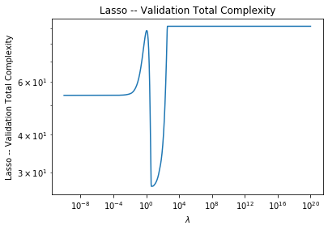

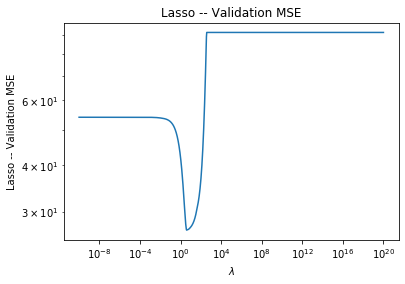

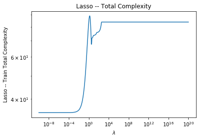

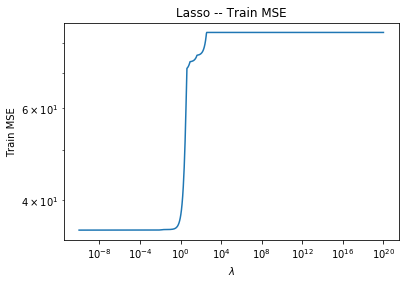

```python
#(c)-4-4
#(c)-4-2
from sklearn.linear_model import Lasso
lamda = 0
lasso_val_complexity = -1
lasso_plot_x = []
lasso_plot_valmse = []
lasso_plot_valcomp = []
lasso_plot_trainmse = []
lasso_plot_traincomp = []

lambdas = [10**i for i in np.linspace(-10,+20,1000)]
for lamda in lambdas:

    lasso_reg = Lasso(alpha=lamda, fit_intercept=True).fit(housing_data_400[['AGE', 'INDUS', 'NOX', 'RM', 'TAX']], housing_data_400['MEDV'])

    lasso_train_hat = lasso_reg.predict( housing_data_400[['AGE', 'INDUS', 'NOX', 'RM', 'TAX']])
    lasso_mse_train = np.sum((housing_data_400['MEDV'] - lasso_train_hat)**2)/len(housing_data_400)
    lasso_train_complexity = lasso_mse_train + lamda * np.sum(lasso_reg.coef_[1:]**2)
    lasso_plot_traincomp.append(lasso_train_complexity)
    lasso_plot_trainmse.append(lasso_mse_train)

    lasso_val_hat = lasso_reg.predict(housing_data_validation[['AGE', 'INDUS', 'NOX', 'RM', 'TAX']])
    lasso_mse_val = np.sum((housing_data_validation['MEDV'] - lasso_val_hat)**2)/len(housing_data_validation)
    lasso_val_complexity = lasso_mse_val + lamda * np.sum(lasso_reg.coef_[1:]**2)
    lasso_plot_valcomp.append(lasso_val_complexity)
    lasso_plot_valmse.append(lasso_mse_val)


plt.figure()
plt.plot(lambdas, lasso_plot_valcomp)
plt.xscale('log')
plt.yscale('log')
plt.xlabel(r"$\lambda$")
plt.ylabel("Lasso -- Validation Total Complexity")
plt.title("Lasso -- Validation Total Complexity")

plt.figure()
plt.plot(lambdas, lasso_plot_valmse)
plt.xscale('log')
plt.yscale('log')
plt.xlabel(r"$\lambda$")
plt.ylabel("Lasso -- Validation MSE")
plt.title("Lasso -- Validation MSE")

plt.figure()
plt.plot(lambdas, lasso_plot_traincomp)
plt.xscale('log')
plt.yscale('log')
plt.xlabel(r"$\lambda$")
plt.ylabel("Lasso -- Train Total Complexity")
plt.title("Lasso -- Total Complexity")

plt.figure()
plt.plot(lambdas, lasso_plot_trainmse)
plt.xscale('log')
plt.yscale('log')
plt.xlabel(r"$\lambda$")
plt.ylabel("Train MSE")
plt.title("Lasso -- Train MSE")
```

```python
ind_min = lasso_plot_valmse.index(min(lasso_plot_valmse))
lasso_reg = Lasso(alpha=lambdas[ind_min], fit_intercept=True).fit(housing_data_400[['AGE', 'INDUS', 'NOX', 'RM', 'TAX']], housing_data_400['MEDV'])
print('Coefficients of best fitting model using Lasso')
print(lasso_reg.intercept_)
print(lasso_reg.coef_)
```

```
Coefficients of best fitting model using Lasso
30.269100425433557
[-0.03168355 -0.18000775 -0.          0.35840347 -0.01280855]
```

Here, some of the coefficients are small, and the coefficient for NOX is set to exactly 0. So Lasso appears to have found a sparser model than Ridge did, although still not as sparse as the model with Mallow's Cp. Recall that penalizing the number of non-zero coefficients is the strictest type of penalty; Ridge allows all the coefficients to remain if they are sufficiently small. Lasso is in between.

2.(c).iv.v For Mallow's Cp, which only counts the number of non-zero coefficients (no matter how big or small), it does not matter. We would get the same linear relationship; the coefficients would adjust to a revised scale.

For Lasso and Ridge regression, which penalize the magnitudes of the coefficients, whether we normalize (to $[0,1]$) or standardize (subtract mean and divide by standard deviation) will affect the coefficient magnitudes and consequently how big the penalty is for a particular model. It certainly is possible that if we changed the scales (standardizing or just measuring in different units), that would effect which model got picked in the end.

In the future, we will usually standardize, but one goal of this homework was for you to think a little about coefficient magnitudes, how they relate to (diverse) feature scales, and if/when that might affect machine learning procedures.

```python
vec_ones = np.full(len(housing_data_400), 1).reshape(-1, 1)
housing_data_validation['MEDV'].shape
```

```
(100,)
```

# 2.(d).i Forward search through all features

```python
# 2.(d).i Forward search through all features, using validation set MSE

# maintain a list of features not added yet
lst_features_remain = list(housing_data.columns)
lst_features_remain.remove('MEDV')
lst_features_added = []

for_steps = [] # keep tuples (p, 'name', valmse) in order added

#get the p=0 model  (sanity check -- it should be the mean np.mean(housing_data_400['MEDV'])=24.334)
vec_400ones = np.full(len(housing_data_400['MEDV']), 1).reshape(-1, 1)
vec_100ones = np.full(len(housing_data_validation['MEDV']), 1).reshape(-1, 1)

housing_reg = housing_fit.fit(vec_400ones, housing_data_400['MEDV'])
medv_hat_val = housing_reg.predict(vec_100ones)
const_mse_val = np.sum((medv_hat_val - housing_data_validation['MEDV'])**2)/len(housing_data_validation['MEDV'])
medv_hat_train= housing_reg.predict(vec_400ones)
const_mse_train = np.sum((medv_hat_train - housing_data_400['MEDV'])**2)/len(housing_data_400['MEDV'])

for_steps.append( (0,'constant',const_mse_val,const_mse_train))
```

```python
housing_fit = LinearRegression(fit_intercept=True) #when we fit, just pass in features, no need column of ones
p = 1
while len( lst_features_remain ) >0:

    bestfeat = None
    bestmse = 10**8

    for feat in lst_features_remain:

        Xtrain = housing_data_400[ lst_features_added + [feat] ]
        Ytrain = housing_data_400['MEDV']

        Xval = housing_data_validation[ lst_features_added + [feat] ]
        Yval = housing_data_validation['MEDV']

        housing_reg = housing_fit.fit( Xtrain, Ytrain )

        medv_hat_train = housing_reg.predict(Xtrain)
        mse_train = np.sum((medv_hat_train - Ytrain)**2)/len(Ytrain)

        medv_hat_val = housing_reg.predict(Xval)
        mse_val = np.sum((medv_hat_val - Yval)**2)/len(Yval)

        print((p,feat,mse_val))

        if mse_val < bestmse:
            bestmse = mse_val
            bestfeat = feat

            print('updating with '+feat)

    for_steps.append( (p,bestfeat,bestmse,mse_train) )
    p += 1
    lst_features_remain.remove(bestfeat)
    lst_features_added.append(bestfeat)
```

```
(1, 'CRIM', 52.566435125561064)
updating with CRIM
(1, 'ZN', 68.13834946166581)
(1, 'INDUS', 37.528985660473694)
updating with INDUS
(1, 'CHAS', 85.35992588102839)
(1, 'NOX', 48.41037077966023)
(1, 'RM', 74.52397883631944)
(1, 'AGE', 60.62934614353593)
(1, 'DIS', 76.89041459711021)
(1, 'RAD', 44.29140556410366)
(1, 'TAX', 27.744035412839594)
updating with TAX
(1, 'PTRATIO', 43.53309744733372)
(1, 'B', 40.18845063300885)
(1, 'LSTAT', 23.031294118421037)
updating with LSTAT
(2, 'CRIM', 23.197237014101265)
updating with CRIM
(2, 'ZN', 22.150651070342484)
updating with ZN
(2, 'INDUS', 23.886529895572604)
(2, 'CHAS', 21.572190772617887)
updating with CHAS
(2, 'NOX', 27.70114118092264)
(2, 'RM', 38.0519198461464)
(2, 'AGE', 28.268447012785032)
(2, 'DIS', 31.134105899065826)
(2, 'RAD', 29.862918430048097)
(2, 'TAX', 21.927918745913804)
(2, 'PTRATIO', 16.189268394664065)
updating with PTRATIO
(2, 'B', 20.815225686079426)
(3, 'CRIM', 17.18255121658856)
updating with CRIM
(3, 'ZN', 16.378735023054585)
updating with ZN
(3, 'INDUS', 17.18665614152012)
(3, 'CHAS', 16.110278291254183)
updating with CHAS
```

[output cut: 67 more lines]

```
updating with AGE
(10, 'RAD', 19.994045903850974)
(10, 'B', 17.890804973990214)
(11, 'RM', 25.225405671312544)
updating with RM
(11, 'RAD', 20.456290166781244)
updating with RAD
(11, 'B', 18.669564194710436)
updating with B
(12, 'RM', 22.3959873395837)
updating with RM
(12, 'RAD', 17.360840115629717)
updating with RAD
(13, 'RM', 37.06643830454897)
updating with RM
```

```python
print('(p, <feature added>, test MSE, train MSE)')
for step in for_steps:
    print(step)
```

```
(p, <feature added>, test MSE, train MSE)
(0, 'constant', 91.60103125000003, 83.80700974999999)
(1, 'LSTAT', 23.031294118421037, 42.621582912638644)
(2, 'PTRATIO', 16.189268394664065, 42.54612266885636)
(3, 'CHAS', 16.110278291254183, 37.321061160175525)
(4, 'ZN', 16.1785349016638, 36.04057630115075)
(5, 'INDUS', 16.41359903858308, 36.02099205430555)
(6, 'TAX', 16.55699876698817, 35.953940453356154)
(7, 'NOX', 16.782737279909266, 35.92010861773848)
(8, 'DIS', 16.219849928458867, 35.858742222798796)
(9, 'CRIM', 15.930804353448778, 30.601718065660993)
(10, 'AGE', 16.61014253735483, 30.587648883957762)
(11, 'B', 18.669564194710436, 30.28257473977117)
(12, 'RAD', 17.360840115629717, 28.17532433907633)
(13, 'RM', 37.06643830454897, 22.30522558416345)
```

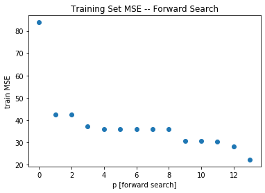

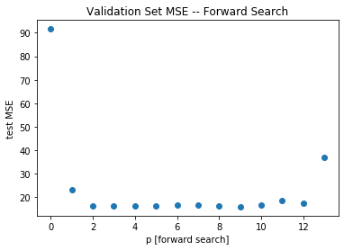

```python
# Plots forward search (all features)

plt.figure()
plt.scatter([tpl[0] for tpl in for_steps], [tpl[3] for tpl in for_steps])
plt.xlabel("p [forward search]")
plt.ylabel("train MSE")
plt.title("Training Set MSE -- Forward Search")
plt.show()

plt.figure()
plt.scatter([tpl[0] for tpl in for_steps], [tpl[2] for tpl in for_steps])
plt.xlabel("p [forward search]")
plt.ylabel("test MSE")
plt.title("Validation Set MSE -- Forward Search")
plt.show()
```

# 2.(d).ii Backward search through all features

```python
#2.(d).ii Backward search through all features, using validation set MSE
#basically a copy of foward search with a few changes

# maintain a list of features not added yet
lst_features_remain = list(housing_data.columns)
lst_features_remain.remove('MEDV')

back_steps = [] # keep tuples (p, 'name', valmse) in order added
```

```python
housing_fit = LinearRegression(fit_intercept=True) #when we fit, just pass in features, no need column of ones
p = len( lst_features_remain )
while len( lst_features_remain ) >1:

    worstfeat = None  #the worst feature is the one that reduces the mse the least
    bestmse = 10**8

    for feat in lst_features_remain:

        #create a copy without feat
        lst_tmp = list(lst_features_remain)
        lst_tmp.remove(feat)

        Xtrain = housing_data_400[ lst_tmp ]
        Ytrain = housing_data_400['MEDV']

        Xval = housing_data_validation[ lst_tmp ]
        Yval = housing_data_validation['MEDV']

        housing_reg = housing_fit.fit( Xtrain, Ytrain )

        medv_hat_train = housing_reg.predict(Xtrain)
        mse_train = np.sum((medv_hat_train - Ytrain)**2)/len(Ytrain)

        medv_hat_val = housing_reg.predict(Xval)
        mse_val = np.sum((medv_hat_val - Yval)**2)/len(Yval)

        print((p,feat,mse_val))

        if mse_val < bestmse:
            bestmse = mse_val
            worstfeat = feat

            print('updating with '+feat)

    back_steps.append( (p,worstfeat,bestmse,mse_train) )
    p -= 1
    lst_features_remain.remove(worstfeat)


#do fit for the last remaining feature
Xtrain = housing_data_400[ lst_features_remain ]
Ytrain = housing_data_400['MEDV']

Xval = housing_data_validation[ lst_features_remain ]
Yval = housing_data_validation['MEDV']

housing_reg = housing_fit.fit( Xtrain, Ytrain )

medv_hat_train = housing_reg.predict(Xtrain)
mse_train = np.sum((medv_hat_train - Ytrain)**2)/len(Ytrain)

medv_hat_val = housing_reg.predict(Xval)
mse_val = np.sum((medv_hat_val - Yval)**2)/len(Yval)

back_steps.append( (p,lst_features_remain[0],mse_val,mse_train) )
print(back_steps[-1] )

back_steps.append( (0,'constant',const_mse_val,const_mse_train) )
```

```
(13, 'CRIM', 33.185811310131)
updating with CRIM
(13, 'ZN', 38.778625501578816)
(13, 'INDUS', 36.480628895636706)
(13, 'CHAS', 40.41211263232214)
(13, 'NOX', 33.03933445566899)
updating with NOX
(13, 'RM', 17.36084011562972)
updating with RM
(13, 'AGE', 37.16842821778827)
(13, 'DIS', 40.69547602885832)
(13, 'RAD', 22.395987339583243)
(13, 'TAX', 35.60348735205875)
(13, 'PTRATIO', 43.467138133187355)
(13, 'B', 35.35240888658152)
(13, 'LSTAT', 64.11149601044127)
(12, 'CRIM', 17.608322506053597)
updating with CRIM
(12, 'ZN', 17.615118933414657)
(12, 'INDUS', 17.39417949455611)
updating with INDUS
(12, 'CHAS', 18.961785926401458)
(12, 'NOX', 20.737777816876438)
(12, 'AGE', 16.690825010912167)
updating with AGE
(12, 'DIS', 21.24001279959392)
(12, 'RAD', 18.669564194710436)
(12, 'TAX', 16.316960709432344)
updating with TAX
(12, 'PTRATIO', 20.894598538788976)
(12, 'B', 20.456290166780818)
(12, 'LSTAT', 20.605705796558023)
(11, 'CRIM', 15.941874967558807)
updating with CRIM
(11, 'ZN', 16.617032615884707)
(11, 'INDUS', 17.450934779430217)
(11, 'CHAS', 18.17115737969747)
(11, 'NOX', 21.024824232686342)
(11, 'AGE', 15.77866693295457)
updating with AGE
```

[output cut: 58 more lines]

```
(4, 'NOX', 32.02896954984605)
updating with NOX
(4, 'RAD', 15.32297535713778)
updating with RAD
(4, 'PTRATIO', 26.216244951749403)
(4, 'B', 36.94978405187326)
(3, 'NOX', 30.242733472415583)
updating with NOX
(3, 'PTRATIO', 33.34883527124655)
(3, 'B', 22.75444891578811)
updating with B
(2, 'NOX', 43.53309744733372)
updating with NOX
(2, 'PTRATIO', 48.41037077966023)
(1, 'PTRATIO', 43.53309744733372, 67.91582740506291)
```

```python
print('(p, <feature removed>, test MSE, train MSE)')
for step in back_steps:
    print(step)
```

```
(p, <feature removed>, test MSE, train MSE)
(13, 'RM', 17.36084011562972, 26.68254282422846)
(12, 'TAX', 16.316960709432344, 46.10670821777135)
(11, 'AGE', 15.77866693295457, 47.19269223220255)
(10, 'CRIM', 15.128271858029839, 47.70181550669371)
(9, 'ZN', 15.478119072351845, 49.95821220381914)
(8, 'INDUS', 16.47072086593156, 51.33007404781162)
(7, 'CHAS', 17.96782031904615, 53.12359208763863)
(6, 'DIS', 19.474764712631824, 54.66364269730749)
(5, 'LSTAT', 18.35120564693482, 58.925811809167975)
(4, 'RAD', 15.32297535713778, 59.27172455682057)
(3, 'B', 22.75444891578811, 60.74797822736477)
(2, 'NOX', 43.53309744733372, 76.09459060678641)
(1, 'PTRATIO', 43.53309744733372, 67.91582740506291)
(0, 'constant', 91.60103125000003, 83.80700974999999)
```

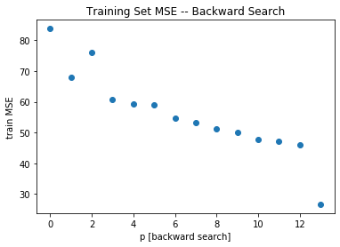

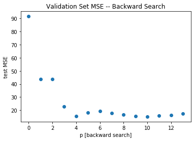

```python
# Plots backward search (all features)

plt.figure()
plt.scatter([tpl[0] for tpl in back_steps], [tpl[3] for tpl in back_steps])
plt.xlabel("p [backward search]")
plt.ylabel("train MSE")
plt.title("Training Set MSE -- Backward Search")
plt.show()

plt.figure()
plt.scatter([tpl[0] for tpl in back_steps], [tpl[2] for tpl in back_steps])
plt.xlabel("p [backward search]")
plt.ylabel("test MSE")
plt.title("Validation Set MSE -- Backward Search")
plt.show()
```

The best model using backward search is larger, {'ZN', 'INDUS', 'CHAS', 'DIS', 'LSTAT', 'RAD', 'B', 'NOX', 'PTRATIO'} with a validation error of 15.12.

2.(d).iii The sequence of models is quite distinct. If we lay out the nesting with $p=1$ first from both searches, we get

Forward search: 'LSTAT' 'PTRATIO' 'CHAS' 'ZN' 'INDUS' 'TAX' 'NOX' 'DIS' 'CRIM' 'AGE''B' 'RAD' 'RM'

Backward search: 'PTRATIO' 'NOX' 'B' 'RAD' 'LSTAT' 'DIS' 'CHAS' 'INDUS' 'ZN' 'CRIM' 'AGE' 'TAX' 'RM'

The most obvious similarity is that PRATIO is included in almost all the models, and RM is the least helpful feature (we discussed why above). We also see features like 'AGE' and 'CRIM' are only included in the larger models (so generally speaking not as helpful).

# 2.(d).iv Ridge on all features

```
Minimizing lambda, valMSE, and coeff are
17148.81969870541
12.839812498898954
  CRIM	-4.3176e-02
    ZN	5.9977e-02
 INDUS	-4.5365e-02
  CHAS	9.2382e-03
   NOX	2.8187e-04
    RM	6.9022e-02
   AGE	2.1797e-02
   DIS	-7.2870e-02
   RAD	8.7026e-02
   TAX	-1.3051e-02
PTRATIO	-1.1094e-01
     B	1.2427e-02
 LSTAT	-4.0383e-01
```

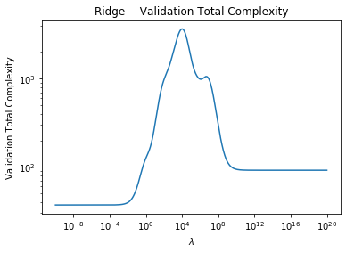

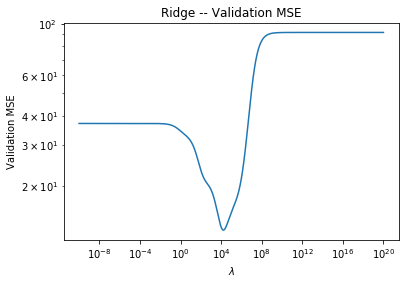

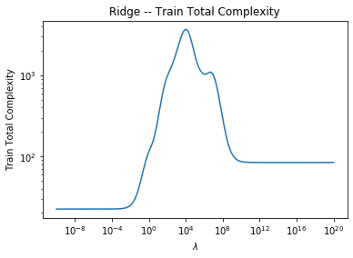

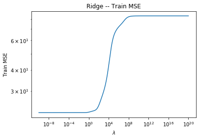

```python
# Ridge
lst_features = list(housing_data.columns)
lst_features.remove('MEDV')
ridge_plot_x = []
ridge_plot_valmse = []
ridge_plot_valcomp = []
ridge_plot_trainmse = []
ridge_plot_traincomp = []

lambdas = [10**i for i in np.linspace(-10,+20,1000)]

Xtrain = housing_data_400[ lst_features ]
Ytrain = housing_data_400['MEDV']

Xval = housing_data_validation[ lst_features ]
Yval = housing_data_validation['MEDV']


for lamda in lambdas:

    ridge_reg = Ridge(alpha=lamda, fit_intercept=True).fit(Xtrain, Ytrain)

    ridge_train_hat = ridge_reg.predict( Xtrain )
    ridge_mse_train = np.sum((Ytrain - ridge_train_hat)**2)/len(Ytrain)
    ridge_train_complexity = ridge_mse_train + lamda * np.sum(ridge_reg.coef_[0:]**2)
    ridge_plot_traincomp.append(ridge_train_complexity)
    ridge_plot_trainmse.append(ridge_mse_train)

    ridge_val_hat = ridge_reg.predict( Xval )
    ridge_mse_val = np.sum(( Yval - ridge_val_hat)**2)/len(Yval)
    ridge_val_complexity = ridge_mse_val + lamda * np.sum(ridge_reg.coef_[0:]**2)
    ridge_plot_valcomp.append(ridge_val_complexity)
    ridge_plot_valmse.append(ridge_mse_val)

# minimizer
argmin = ridge_plot_valmse.index( min(ridge_plot_valmse) )
print('Minimizing lambda, valMSE, and coeff are ')
print(lambdas[argmin])
print(ridge_plot_valmse[argmin])

#refit to get the coeff for the best model
ridge_reg = Ridge(alpha=lambdas[argmin], fit_intercept=True).fit(Xtrain, Ytrain)
for i in range(len(lst_features)):
    print('%6s\t%.4e'%(lst_features[i], ridge_reg.coef_[i]))

#plots
plt.figure()
plt.plot(lambdas, ridge_plot_valcomp)
plt.xscale('log')
plt.yscale('log')
plt.xlabel(r"$\lambda$")
plt.ylabel("Validation Total Complexity")
plt.title("Ridge -- Validation Total Complexity")

plt.figure()
plt.plot(lambdas, ridge_plot_valmse)
plt.xscale('log')
plt.yscale('log')
plt.xlabel(r"$\lambda$")
plt.ylabel("Validation MSE")
plt.title("Ridge -- Validation MSE")

plt.figure()
plt.plot(lambdas, ridge_plot_traincomp)
plt.xscale('log')
plt.yscale('log')
plt.xlabel(r"$\lambda$")
plt.ylabel("Train Total Complexity")
plt.title("Ridge -- Train Total Complexity")

plt.figure()
plt.plot(lambdas, ridge_plot_trainmse)
plt.xscale('log')
plt.yscale('log')
plt.xlabel(r"$\lambda$")
plt.ylabel("Train MSE")
plt.title("Ridge -- Train MSE")
```

Using Ridge regression on all features, we see all coefficients are set to non-zero values. Many are on the order of 0.01. NOX's coefficient is 2.8187e-04 which is notable since the magnitude of its feature values is also on a small scale [0,1] while other features are on larger scales. Since it keeps all features, with a possible exception of NOX which we can interpret as almost being removed, the model returned by Ridge regression is quite different than that from forward search (which only kept three features) and even backward search (which kept nine features, including NOX).

# 2.(d).iv LASSO on all features

```
Minimizing lambda, valMSE, and coeff are
11.247371783647507
15.89574200968235
  CRIM	-0.0000e+00
    ZN	2.6169e-02
 INDUS	-0.0000e+00
  CHAS	0.0000e+00
   NOX	0.0000e+00
    RM	0.0000e+00
   AGE	9.4476e-03
   DIS	-0.0000e+00
   RAD	0.0000e+00
   TAX	-7.0628e-03
PTRATIO	-0.0000e+00
     B	4.3609e-03
 LSTAT	-6.2671e-01
```

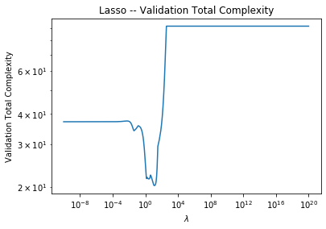

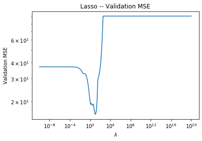

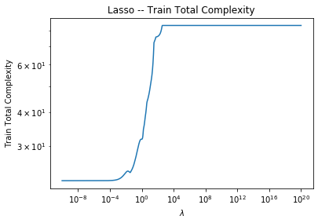

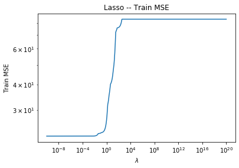

```python
# Lasso
lst_features = list(housing_data.columns)
lst_features.remove('MEDV')
lasso_plot_x = []
lasso_plot_valmse = []
lasso_plot_valcomp = []
lasso_plot_trainmse = []
lasso_plot_traincomp = []

lambdas = [10**i for i in np.linspace(-10,+20,1000)]

Xtrain = housing_data_400[ lst_features ]
Ytrain = housing_data_400['MEDV']

Xval = housing_data_validation[ lst_features ]
Yval = housing_data_validation['MEDV']


for lamda in lambdas:

    lasso_reg = Lasso(alpha=lamda, fit_intercept=True).fit(Xtrain, Ytrain)

    lasso_train_hat = lasso_reg.predict( Xtrain )
    lasso_mse_train = np.sum((Ytrain - lasso_train_hat)**2)/len(Ytrain)
    lasso_train_complexity = lasso_mse_train + lamda * np.sum(lasso_reg.coef_[0:]**2)
    lasso_plot_traincomp.append(lasso_train_complexity)
    lasso_plot_trainmse.append(lasso_mse_train)

    lasso_val_hat = lasso_reg.predict( Xval )
    lasso_mse_val = np.sum(( Yval - lasso_val_hat)**2)/len(Yval)
    lasso_val_complexity = lasso_mse_val + lamda * np.sum(lasso_reg.coef_[0:]**2)
    lasso_plot_valcomp.append(lasso_val_complexity)
    lasso_plot_valmse.append(lasso_mse_val)

# minimizer
argmin = lasso_plot_valmse.index( min(lasso_plot_valmse) )
print('Minimizing lambda, valMSE, and coeff are ')
print(lambdas[argmin])
print(lasso_plot_valmse[argmin])

lasso_reg = Lasso(alpha=lambdas[argmin], fit_intercept=True).fit(Xtrain, Ytrain)

for i in range(len(lst_features)):
    print('%6s\t%.4e'%(lst_features[i], lasso_reg.coef_[i]))

#plots
plt.figure()
plt.plot(lambdas, lasso_plot_valcomp)
plt.xscale('log')
plt.yscale('log')
plt.xlabel(r"$\lambda$")
plt.ylabel("Validation Total Complexity")
plt.title("Lasso -- Validation Total Complexity")

plt.figure()
plt.plot(lambdas, lasso_plot_valmse)
plt.xscale('log')
plt.yscale('log')
plt.xlabel(r"$\lambda$")
plt.ylabel("Validation MSE")
plt.title("Lasso -- Validation MSE")

plt.figure()
plt.plot(lambdas, lasso_plot_traincomp)
plt.xscale('log')
plt.yscale('log')
plt.xlabel(r"$\lambda$")
plt.ylabel("Train Total Complexity")
plt.title("Lasso -- Train Total Complexity")

plt.figure()
plt.plot(lambdas, lasso_plot_trainmse)
plt.xscale('log')
plt.yscale('log')
plt.xlabel(r"$\lambda$")
plt.ylabel("Train MSE")
plt.title("Lasso -- Train MSE")
```

Using LASSO on all features, we see many coefficients are set to 0, such as CRIM, INDUS, CHAS, and several others. This is in stark contrast to the model found with Ridge regression. The only features that have non-zero coefficients in the Lasso model are

ZN, AGE, TAX, B, and LSTAT,

and that set (for the particular coefficients chosen) have validation MSE of 15.8. Interestingly, these variables do not quite align closely with either Backward or Forward searches.

For instance, similar to forward search, LASSO keeps LSTAT, but LASSO also keeps AGE and B which forward search only included at the end.

Similar to backward search, LASSO included B, LSTAT, ZN; however, LASSO also kept AGE and TAX among its small set of features while backward search discarded those early on.